# EDS_230_Growth_Assignment

Clarissa Boyajian, Ryan Munnikhuis, and Marie Rivers

2022-05-15

# Growth Assignment

```r
library(deSolve)
library(here)
library(sensitivity)
library(tidyverse)
library(patchwork)
```

## Background

Consider the following model of forest growth (where forest size is measured in units of carbon (C)):

$$dC/dt = r * C$$

for forest where **C is below a threshold canopy closure** and

$$dC/dt = g * (1 = C/K)$$

for forests where **carbon is at or above the threshold canopy closure**

and K is a carrying capacity in units of Carbon. The size of the forest (C), canopy closure threshold and carrying capacity are all in units of carbon. Think of the canopy closure threshold as the size of the forest at which growth rates change from exponential to linear. Think of *r* as the early exponential growth rate and *g* as the linear growth rate once canopy closure has been reached.

C = forest size, units of carbon

T = time, years

r = early exponential growth rate (before canopy closure has been reached)

g = the linear growth rate once canopy closure has been reached

K = carrying capacity, units of carbon

canopy closure threshold = the size of the forest at which growth rates change from exponential to linear

**1. Implement this model in R as a differential equation**

```r
source(here("R", "dforest_growth.R"))

dforest_growth
```

```
## function (Time, C, parms)
## {
##     if (C < parms$canopy_threshold) {
##         dC_dt <- parms$r * C
##     }
##     else if (C >= parms$canopy_threshold) {
##         dC_dt <- parms$g * (1 - C/parms$K)
##     }
##     return(list(dC_dt))
## }
```

**2. Run the model for 300 years (using the ODE solver) starting with an initial forest size of 10 kg Carbon and using the following parameters:** canopy closure threshold = 50 kg Carbon

K = 250 kg C (carrying capacity)

r = 0.01 (exponential growth rate before canopy closure)

g = 2 kg/year (linear growth rate after canopy closure)

```r
years <- seq(from = 1, to = 300) # time sequence of years
Cinitial <- 10 # initial forest size, kg Carbon
canopy_threshold <- 50 # kg Carbon
K <- 250 # carrying capacity, kg C
r <- 0.01 # exponential growth rate before canopy closure)
g <- 2 # linear growth rate after canopy closure, kg/year

# set up parameter list
parms <- list(canopy_threshold = canopy_threshold, K = K, r = r, g = g)

results <- ode(y = Cinitial, times = years, func = dforest_growth, parms = parms, method = "lsoda")

colnames(results) = c("year", "carbon")
```

Graph the results

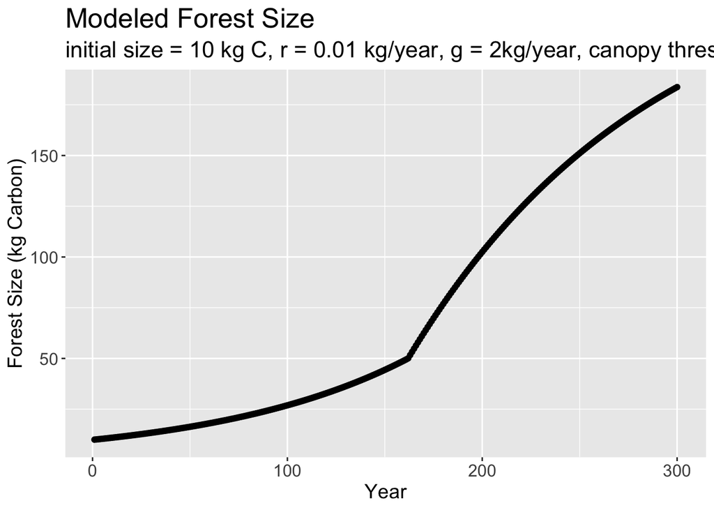

```r
carbon_graph <- ggplot(data = as.data.frame(results),
                       aes(x = year, y = carbon)) +
  geom_point() +
  labs(x = "Year", y = "Forest Size (kg Carbon)",
       title = "Modeled Forest Size",
       subtitle = paste0("initial size = ", Cinitial, " kg C, r = ",
                         r, " kg/year, g = ", g, "kg/year, canopy threshold = ",
                         canopy_threshold, "kg C, carrying capacity = ", K, " kg C")) +
  theme(title = element_text(size = 16),
        axis.title = element_text(size = 14),
        axis.text = element_text(size = 12))
carbon_graph
```

```r
# check that units are stated correctly
```

**3. Run a sobol sensitivity analysis that explores how the estimated maximum and mean forest size (e.g. maximum and mean values of C over the 300 years) varies with the pre canopy closure growth rate (*r*) and post-canopy closure rate (*g*) and canopy closure threshold and carrying capacity (K).**

Assume that the parameters are all normally distributed with means as given above and standard deviation of 10% of mean value.

```r
# want to learn about sensitivity with all the parameters normally distributed
# set the number of parameters
np <- 100

r <- rnorm(mean = r, sd = 0.1 * r, n = np)
g <- rnorm(mean = g, sd = 0.1 * g, n = np)
canopy_threshold <- rnorm(mean = canopy_threshold,
                          sd = 0.1 * canopy_threshold, n = np)
K <- rnorm(mean = K, sd = 0.1 * K, n = np)
X1 = cbind.data.frame(r = r, g = g, canopy_threshold = canopy_threshold, K = K)

# repeat to get our second set of samples
r <- rnorm(mean = r, sd = 0.1 * r, n = np)
g <- rnorm(mean = g, sd = 0.1 * g, n = np)
canopy_threshold <- rnorm(mean = canopy_threshold, sd = 0.1 * canopy_threshold, n = np)
K <- rnorm(mean = K, sd = 0.1 * K, n = np)
X2 = cbind.data.frame(r = r, g = g, canopy_threshold = canopy_threshold, K = K)

# create  sobel object and get sets of parameters for running the model
sens_Carbon = sobolSalt(model = NULL, X1, X2, nboot = 300)

# our parameter sets are
head(sens_Carbon$X)
```

```
##             [,1]     [,2]     [,3]     [,4]
## [1,] 0.009100777 2.091209 49.89627 221.6431
## [2,] 0.011402886 1.797722 47.95096 260.9338
## [3,] 0.011164198 1.875845 50.17727 229.2470
## [4,] 0.009919905 2.224818 47.26182 208.3111
## [5,] 0.009581382 1.830911 53.75370 231.6808
## [6,] 0.010821611 1.894989 38.26446 257.0826
```

```r
# lets add names
colnames(sens_Carbon$X) = c("r", "g", "canopy_threshold", "K")
head(sens_Carbon$X)
```

```
##                r        g canopy_threshold        K
## [1,] 0.009100777 2.091209         49.89627 221.6431
## [2,] 0.011402886 1.797722         47.95096 260.9338
## [3,] 0.011164198 1.875845         50.17727 229.2470
## [4,] 0.009919905 2.224818         47.26182 208.3111
## [5,] 0.009581382 1.830911         53.75370 231.6808
## [6,] 0.010821611 1.894989         38.26446 257.0826
```

Create two additional functions that will compute the metrics we want and run the ODE solver and compute the metrics (a wrapper function that is a workflow to call the ODE solver and then compute metrics)

```r
compute_metrics <- function(result) {

  maxC <- max(result$carbon)
  meanC <- mean(result$carbon)
  return(list(maxC = maxC, meanC = meanC))

}

# try function on first parameter set
compute_metrics(as.data.frame(results))
```

```
## $maxC
## [1] 183.7213
##
## $meanC
## [1] 72.98569
```